# Homework 3 - Forecasting Solar Power Production with ARIMA Models

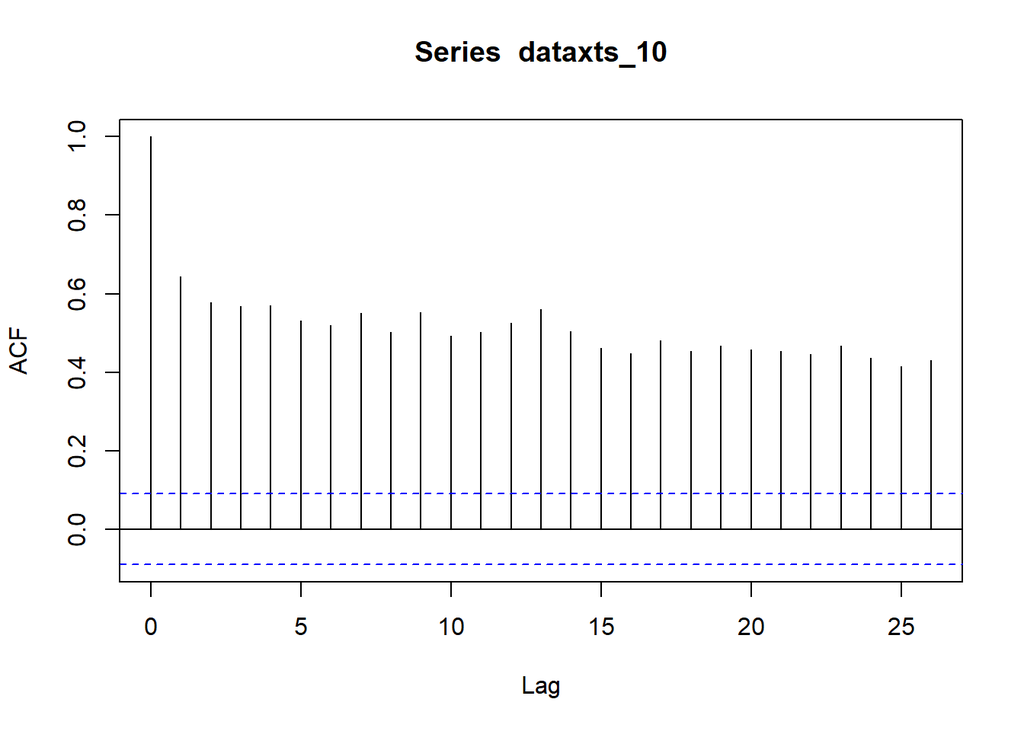

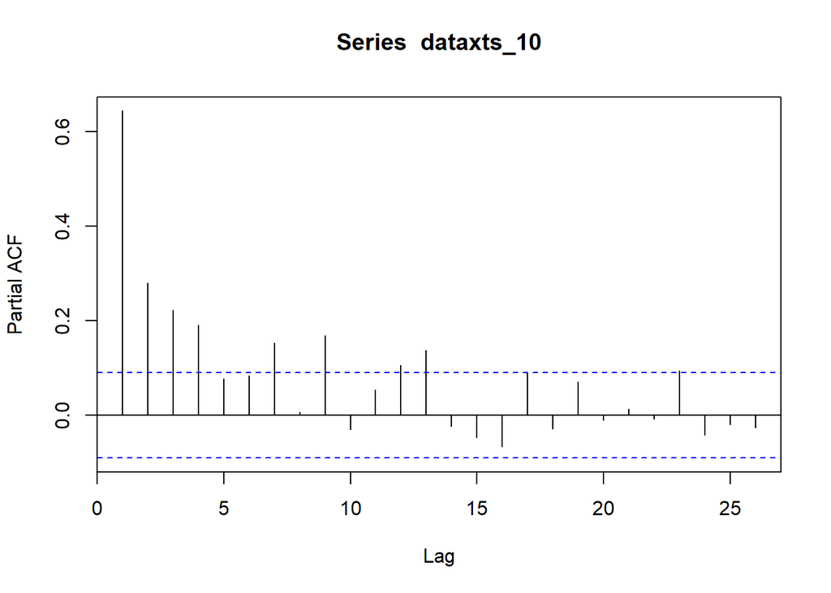

```
##
## #######################
## # KPSS Unit Root Test #
## #######################
##
## Test is of type: mu with 5 lags.
##
## Value of test-statistic is: 1.1878
##
## Critical value for a significance level of:
##                 10pct  5pct 2.5pct  1pct
## critical values 0.347 0.463  0.574 0.739
```

```
##
## #######################
## # KPSS Unit Root Test #
## #######################
##
## Test is of type: mu with 5 lags.
##
## Value of test-statistic is: 1.275
##
## Critical value for a significance level of:
##                 10pct  5pct 2.5pct  1pct
## critical values 0.347 0.463  0.574 0.739
```

```
##
## #######################
## # KPSS Unit Root Test #
## #######################
##
## Test is of type: mu with 5 lags.
##
## Value of test-statistic is: 0.026
##
## Critical value for a significance level of:
##                 10pct  5pct 2.5pct  1pct
## critical values 0.347 0.463  0.574 0.739
```

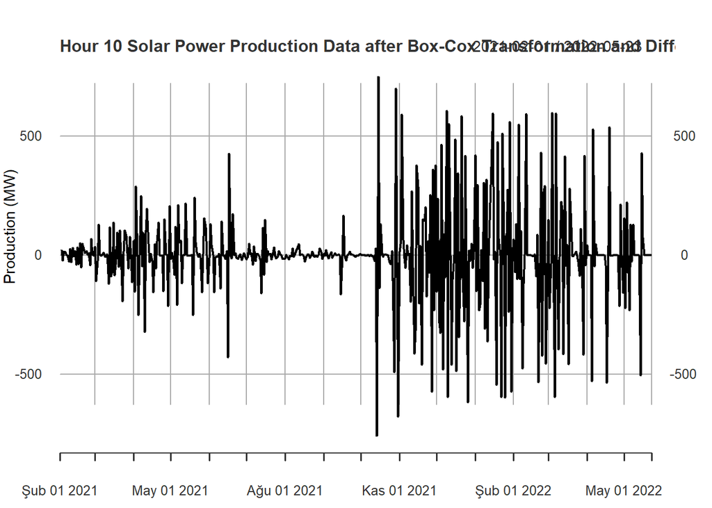

```
##
##  Fitting models using approximations to speed things up...
##
##  ARIMA(2,1,2) with drift         : Inf
##  ARIMA(0,1,0) with drift         : 6330.005
##  ARIMA(1,1,0) with drift         : 6256.596
##  ARIMA(0,1,1) with drift         : 6154.621
##  ARIMA(0,1,0)                    : 6328.007
##  ARIMA(1,1,1) with drift         : 6144.748
##  ARIMA(2,1,1) with drift         : 6147.642
##  ARIMA(1,1,2) with drift         : 6146.562
##  ARIMA(0,1,2) with drift         : 6143.618
##  ARIMA(0,1,3) with drift         : 6145.587
##  ARIMA(1,1,3) with drift         : Inf
##  ARIMA(0,1,2)                    : 6142.734
##  ARIMA(0,1,1)                    : 6153.428
##  ARIMA(1,1,2)                    : 6145.641
##  ARIMA(0,1,3)                    : 6144.709
##  ARIMA(1,1,1)                    : 6143.844
##  ARIMA(1,1,3)                    : 6147.54
##
##  Now re-fitting the best model(s) without approximations...
##
##  ARIMA(0,1,2)                    : 6154.502
##
##  Best model: ARIMA(0,1,2)
```

```
## Series: box_10
## ARIMA(0,1,2)
##
## Coefficients:
##           ma1      ma2
##       -0.6879  -0.1610
## s.e.   0.0449   0.0439
##
## sigma^2 = 28161:  log likelihood = -3074.23
## AIC=6154.45   AICc=6154.5   BIC=6166.91
```

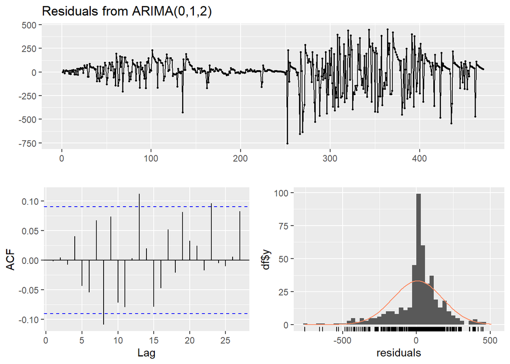

```
##
##  Ljung-Box test
##
## data:  Residuals from ARIMA(0,1,2)
## Q* = 16.137, df = 8, p-value = 0.04046
##
## Model df: 2.   Total lags used: 10
```

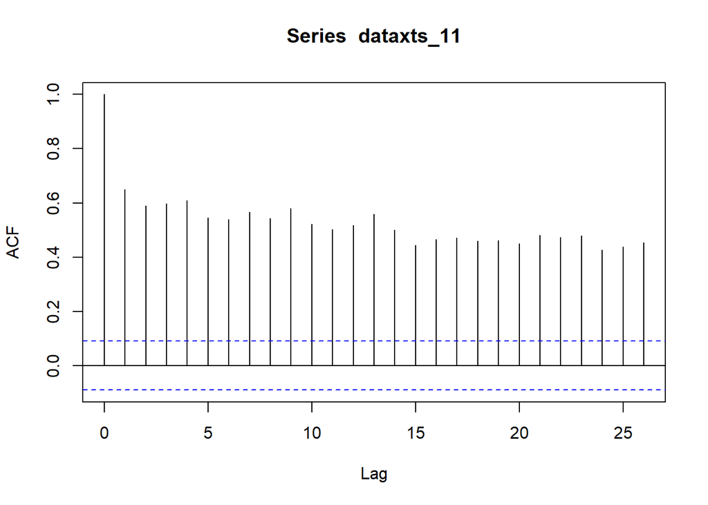

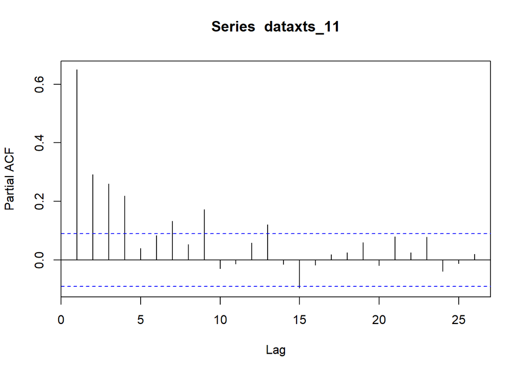

```
##
## #######################
## # KPSS Unit Root Test #
## #######################
##
## Test is of type: mu with 5 lags.
##
## Value of test-statistic is: 1.2752
##
## Critical value for a significance level of:
##                 10pct  5pct 2.5pct  1pct
## critical values 0.347 0.463  0.574 0.739
```

```
##
## #######################
## # KPSS Unit Root Test #
## #######################
##
## Test is of type: mu with 5 lags.
##
## Value of test-statistic is: 1.3134
##
## Critical value for a significance level of:
##                 10pct  5pct 2.5pct  1pct
## critical values 0.347 0.463  0.574 0.739
```

```
##
## #######################
## # KPSS Unit Root Test #
## #######################
##
## Test is of type: mu with 5 lags.
##
## Value of test-statistic is: 0.0278
##
## Critical value for a significance level of:
##                 10pct  5pct 2.5pct  1pct
## critical values 0.347 0.463  0.574 0.739
```

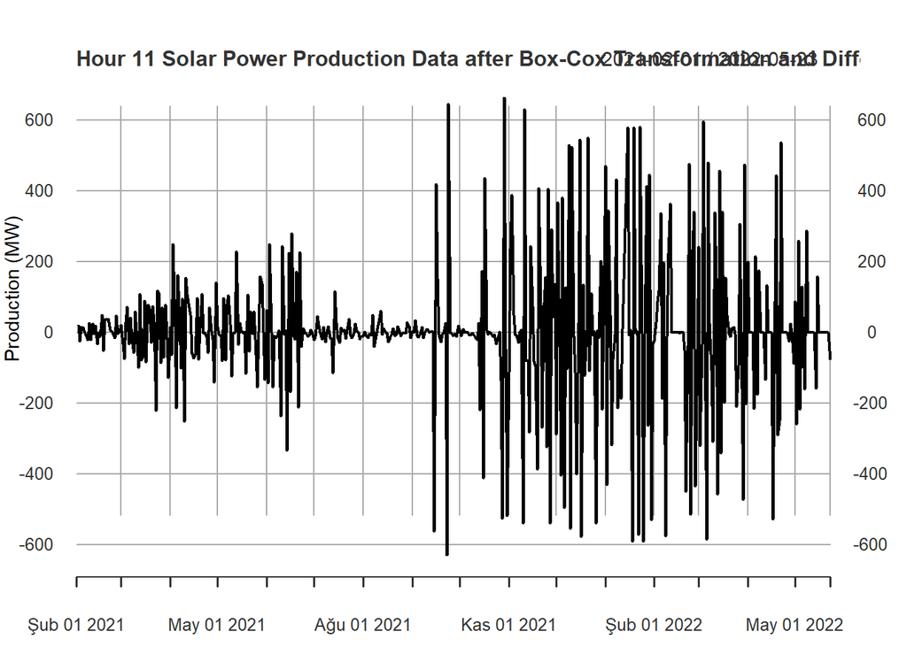

```
##
##  Fitting models using approximations to speed things up...
##
##  ARIMA(2,1,2) with drift         : 6116.676
##  ARIMA(0,1,0) with drift         : 6319.573
##  ARIMA(1,1,0) with drift         : 6225.606
##  ARIMA(0,1,1) with drift         : 6113.176
##  ARIMA(0,1,0)                    : 6317.571
##  ARIMA(1,1,1) with drift         : 6111.615
##  ARIMA(2,1,1) with drift         : 6114.682
##  ARIMA(1,1,2) with drift         : 6113.619
##  ARIMA(0,1,2) with drift         : 6110.586
##  ARIMA(0,1,3) with drift         : 6112.629
##  ARIMA(1,1,3) with drift         : Inf
##  ARIMA(0,1,2)                    : 6109.735
##  ARIMA(0,1,1)                    : 6112.08
##  ARIMA(1,1,2)                    : 6112.711
##  ARIMA(0,1,3)                    : 6111.767
##  ARIMA(1,1,1)                    : 6110.738
##  ARIMA(1,1,3)                    : Inf
##
##  Now re-fitting the best model(s) without approximations...
##
##  ARIMA(0,1,2)                    : 6121.498
##
##  Best model: ARIMA(0,1,2)
```

```
## Series: box_11
## ARIMA(0,1,2)
##
## Coefficients:
##           ma1      ma2
##       -0.7468  -0.0978
## s.e.   0.0460   0.0462
##
## sigma^2 = 26251:  log likelihood = -3057.72
## AIC=6121.45   AICc=6121.5   BIC=6133.9
```

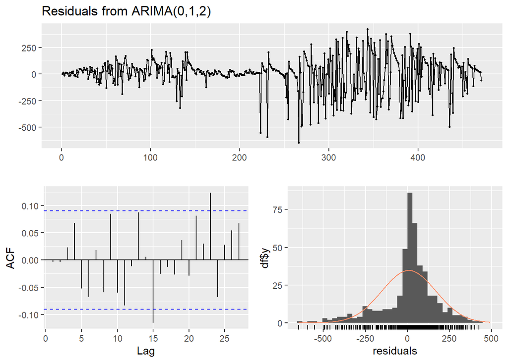

```
##
##  Ljung-Box test
##
## data:  Residuals from ARIMA(0,1,2)
## Q* = 12.981, df = 8, p-value = 0.1125
##
## Model df: 2.   Total lags used: 10
```

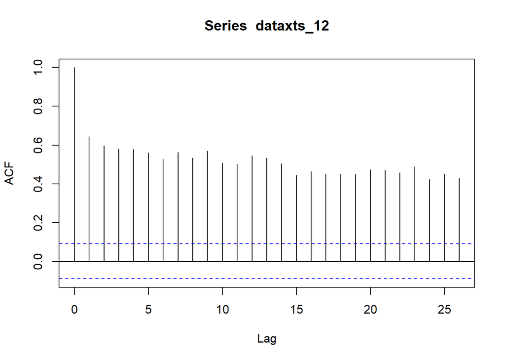

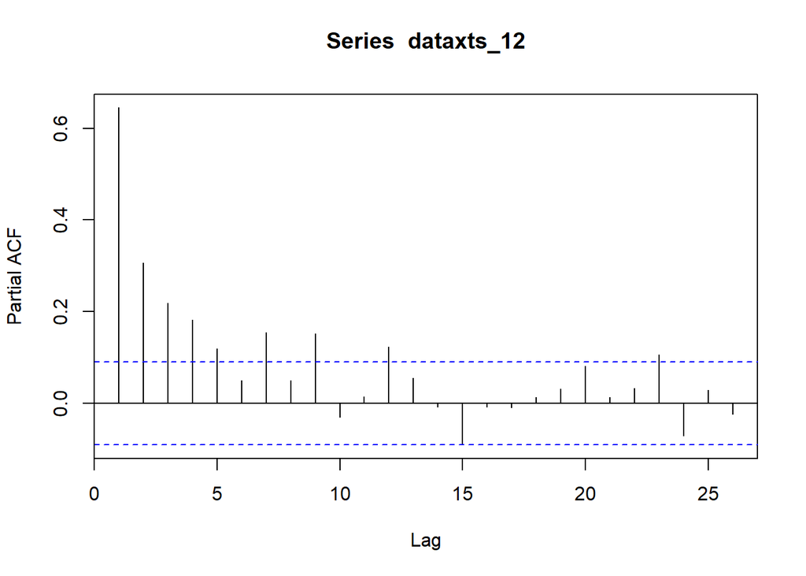

```
##
## #######################
## # KPSS Unit Root Test #
## #######################
##
## Test is of type: mu with 5 lags.
##
## Value of test-statistic is: 1.2649
##
## Critical value for a significance level of:
##                 10pct  5pct 2.5pct  1pct
## critical values 0.347 0.463  0.574 0.739
```

```
##
## #######################
## # KPSS Unit Root Test #
## #######################
##
## Test is of type: mu with 5 lags.
##
## Value of test-statistic is: 1.2772
##
## Critical value for a significance level of:
##                 10pct  5pct 2.5pct  1pct
## critical values 0.347 0.463  0.574 0.739
```

```
##
## #######################
## # KPSS Unit Root Test #
## #######################
##
## Test is of type: mu with 5 lags.
##
## Value of test-statistic is: 0.0266
##
## Critical value for a significance level of:
##                 10pct  5pct 2.5pct  1pct
## critical values 0.347 0.463  0.574 0.739
```

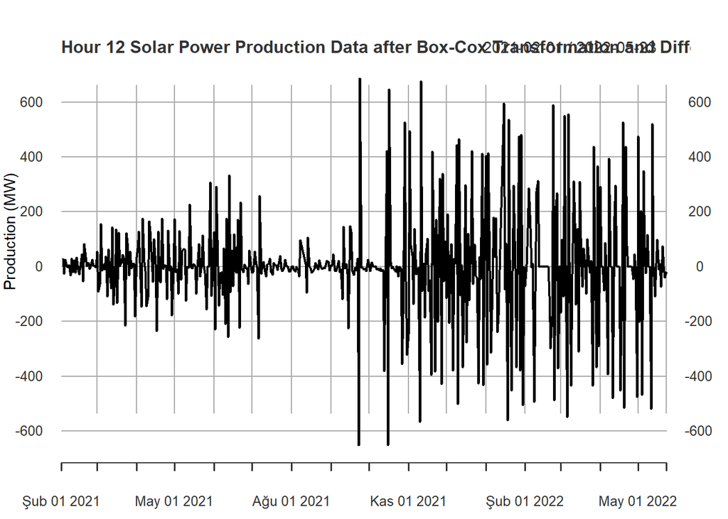

```
##
##  Fitting models using approximations to speed things up...
##
##  ARIMA(2,1,2) with drift         : 6099.048
##  ARIMA(0,1,0) with drift         : 6302.354
##  ARIMA(1,1,0) with drift         : 6205.906
##  ARIMA(0,1,1) with drift         : 6096.27
##  ARIMA(0,1,0)                    : 6300.354
##  ARIMA(1,1,1) with drift         : 6093.952
##  ARIMA(2,1,1) with drift         : 6097.027
##  ARIMA(1,1,2) with drift         : 6095.952
##  ARIMA(0,1,2) with drift         : 6093.166
##  ARIMA(0,1,3) with drift         : 6095.065
##  ARIMA(1,1,3) with drift         : 6098.095
##  ARIMA(0,1,2)                    : 6092.339
##  ARIMA(0,1,1)                    : 6095.233
##  ARIMA(1,1,2)                    : 6095.077
##  ARIMA(0,1,3)                    : 6094.253
##  ARIMA(1,1,1)                    : 6093.08
##  ARIMA(1,1,3)                    : 6097.219
##
##  Now re-fitting the best model(s) without approximations...
##
##  ARIMA(0,1,2)                    : 6104.06
##
##  Best model: ARIMA(0,1,2)
```

```
## Series: box_12
## ARIMA(0,1,2)
##
## Coefficients:
##           ma1      ma2
##       -0.7507  -0.1002
## s.e.   0.0453   0.0447
##
## sigma^2 = 25293:  log likelihood = -3049
## AIC=6104.01   AICc=6104.06   BIC=6116.47
```

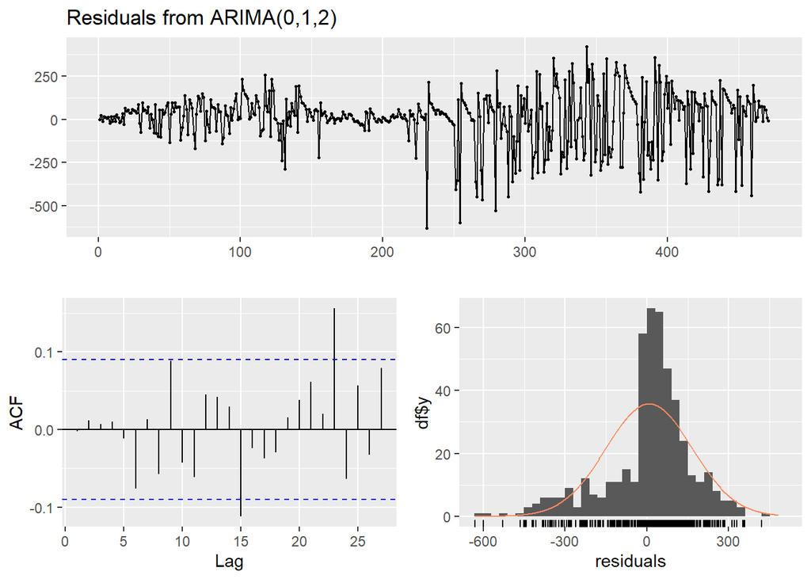

```
##
##  Ljung-Box test
##
## data:  Residuals from ARIMA(0,1,2)
## Q* = 9.3054, df = 8, p-value = 0.3172
##
## Model df: 2.   Total lags used: 10
```

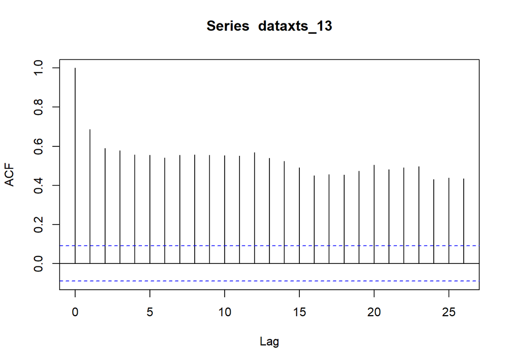

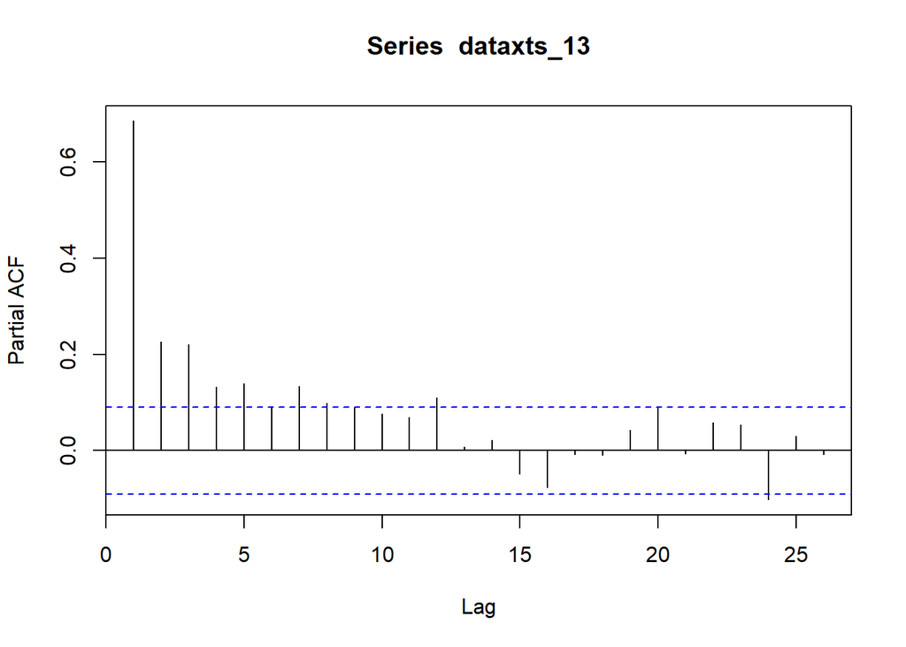

```
##
## #######################
## # KPSS Unit Root Test #
## #######################
##
## Test is of type: mu with 5 lags.
##
## Value of test-statistic is: 1.3875
##
## Critical value for a significance level of:
##                 10pct  5pct 2.5pct  1pct
## critical values 0.347 0.463  0.574 0.739
```

```
##
## #######################
## # KPSS Unit Root Test #
## #######################
##
## Test is of type: mu with 5 lags.
##
## Value of test-statistic is: 1.3776
##
## Critical value for a significance level of:
##                 10pct  5pct 2.5pct  1pct
## critical values 0.347 0.463  0.574 0.739
```

```
##
## #######################
## # KPSS Unit Root Test #
## #######################
##
## Test is of type: mu with 5 lags.
##
## Value of test-statistic is: 0.0441
##
## Critical value for a significance level of:
##                 10pct  5pct 2.5pct  1pct
## critical values 0.347 0.463  0.574 0.739
```

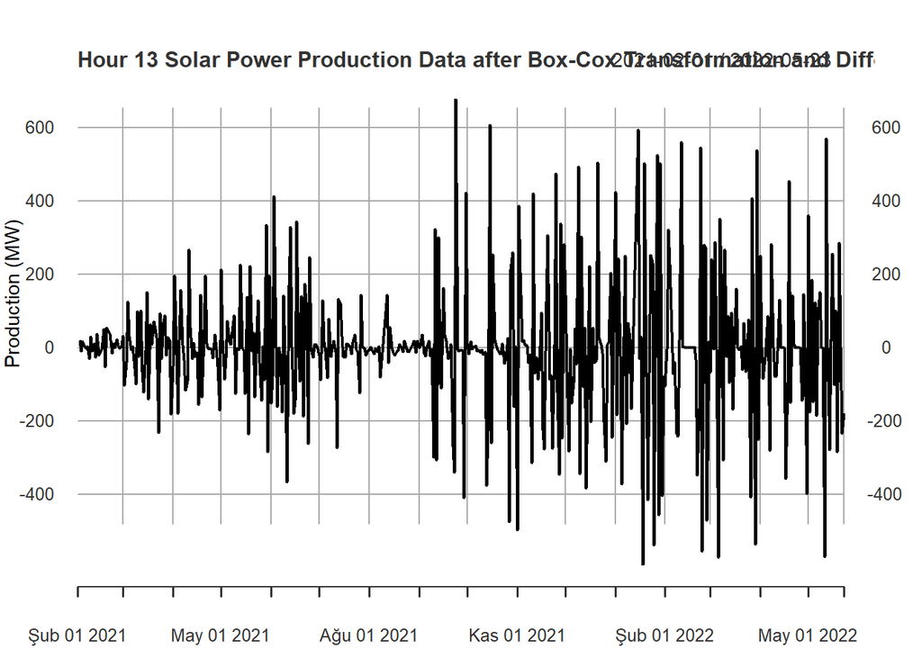

```
##
##  Fitting models using approximations to speed things up...
##
##  ARIMA(2,1,2) with drift         : 6080.249
##  ARIMA(0,1,0) with drift         : 6253.68
##  ARIMA(1,1,0) with drift         : 6189.084
##  ARIMA(0,1,1) with drift         : 6092.853
##  ARIMA(0,1,0)                    : 6251.665
##  ARIMA(1,1,2) with drift         : 6078.651
##  ARIMA(0,1,2) with drift         : 6075.679
##  ARIMA(0,1,3) with drift         : 6077.72
##  ARIMA(1,1,1) with drift         : 6077.284
##  ARIMA(1,1,3) with drift         : 6079.202
##  ARIMA(0,1,2)                    : 6074.545
##  ARIMA(0,1,1)                    : 6091.448
##  ARIMA(1,1,2)                    : 6077.469
##  ARIMA(0,1,3)                    : 6076.576
##  ARIMA(1,1,1)                    : 6076.119
##  ARIMA(1,1,3)                    : 6078.036
##
##  Now re-fitting the best model(s) without approximations...
##
##  ARIMA(0,1,2)                    : 6086.153
##
##  Best model: ARIMA(0,1,2)
```

```
## Series: box_13
## ARIMA(0,1,2)
##
## Coefficients:
##           ma1      ma2
##       -0.6601  -0.1978
## s.e.   0.0458   0.0446
##
## sigma^2 = 24348:  log likelihood = -3040.05
## AIC=6086.1   AICc=6086.15   BIC=6098.56
```

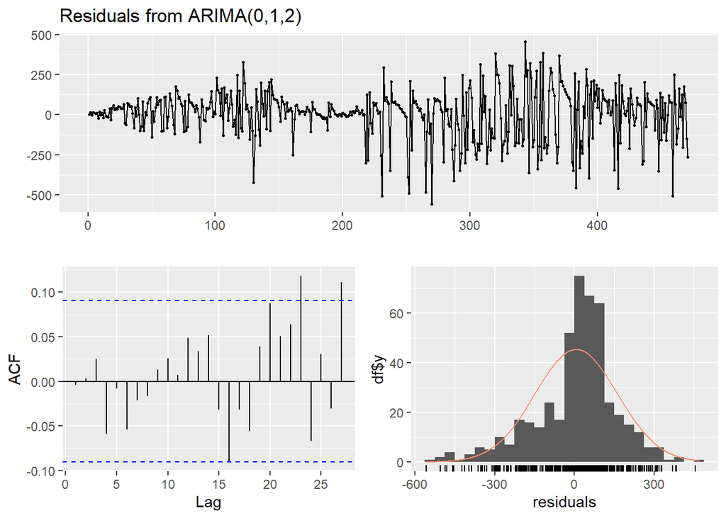

```
##
##  Ljung-Box test
##
## data:  Residuals from ARIMA(0,1,2)
## Q* = 4.1483, df = 8, p-value = 0.8435
##
## Model df: 2.   Total lags used: 10
```

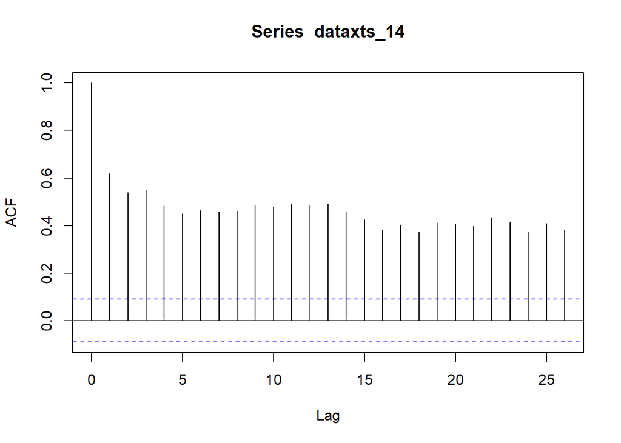

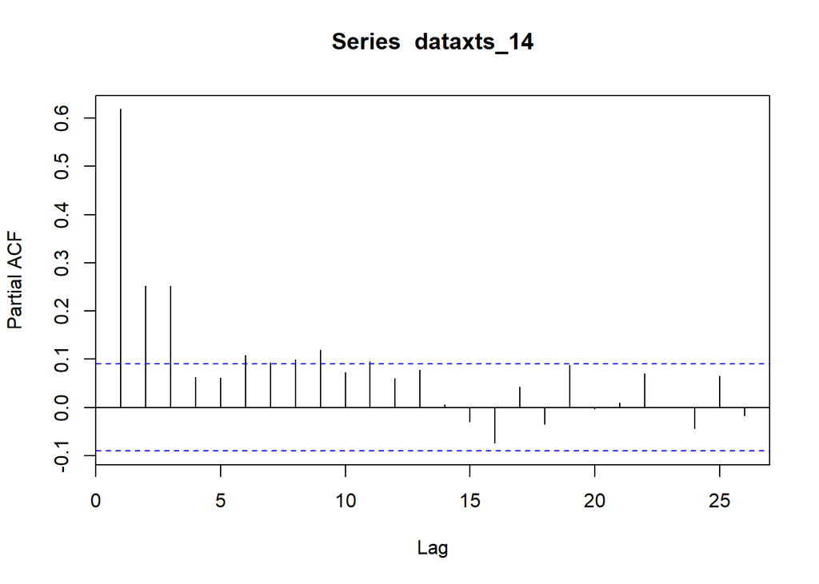

```
##
## #######################
## # KPSS Unit Root Test #
## #######################
##
## Test is of type: mu with 5 lags.
##
## Value of test-statistic is: 1.1838
##
## Critical value for a significance level of:
##                 10pct  5pct 2.5pct  1pct
## critical values 0.347 0.463  0.574 0.739
```

```
##
## #######################
## # KPSS Unit Root Test #
## #######################
##
## Test is of type: mu with 5 lags.
##
## Value of test-statistic is: 1.2444
##
## Critical value for a significance level of:
##                 10pct  5pct 2.5pct  1pct
## critical values 0.347 0.463  0.574 0.739
```

```
##
## #######################
## # KPSS Unit Root Test #
## #######################
##
## Test is of type: mu with 5 lags.
##
## Value of test-statistic is: 0.0302
##
## Critical value for a significance level of:
##                 10pct  5pct 2.5pct  1pct
## critical values 0.347 0.463  0.574 0.739
```

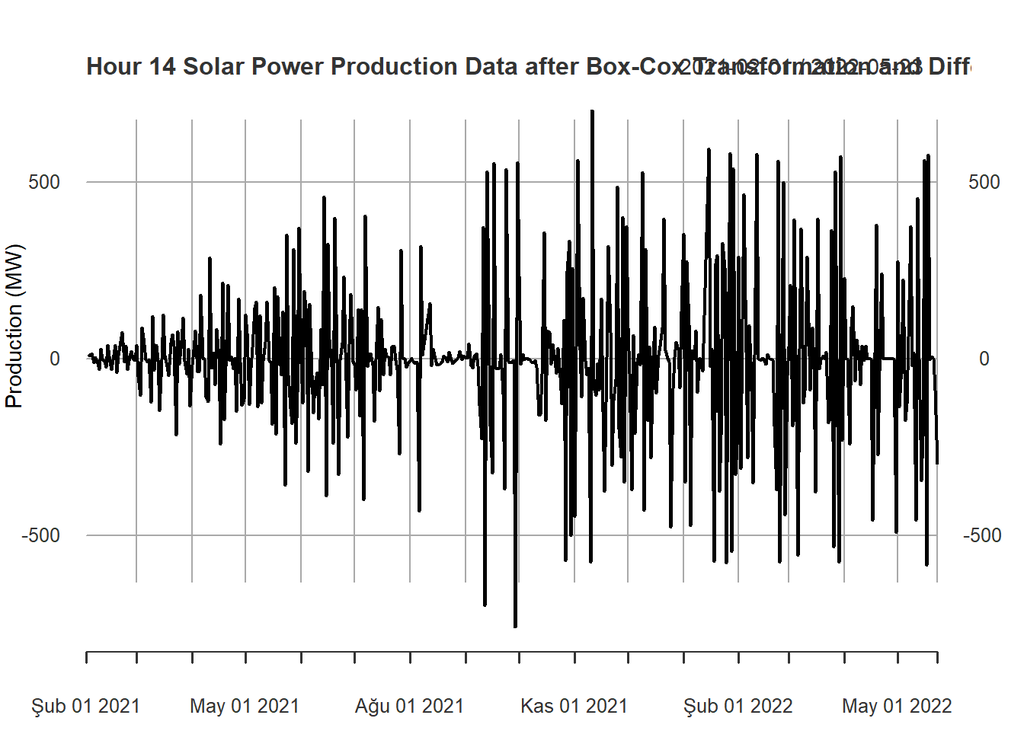

```
##
##  Fitting models using approximations to speed things up...
##
##  ARIMA(2,1,2) with drift         : 6201.309
##  ARIMA(0,1,0) with drift         : 6390.876
##  ARIMA(1,1,0) with drift         : 6306.541
##  ARIMA(0,1,1) with drift         : 6211.444
##  ARIMA(0,1,0)                    : 6388.861
##  ARIMA(1,1,2) with drift         : 6202.595
##  ARIMA(2,1,1) with drift         : 6204.445
##  ARIMA(3,1,2) with drift         : 6202.598
##  ARIMA(2,1,3) with drift         : 6201.009
##  ARIMA(1,1,3) with drift         : 6201.583
##  ARIMA(3,1,3) with drift         : 6202.299
##  ARIMA(2,1,4) with drift         : 6201.397
##  ARIMA(1,1,4) with drift         : 6199.397
##  ARIMA(0,1,4) with drift         : 6196.622
##  ARIMA(0,1,3) with drift         : 6203.269
##  ARIMA(0,1,5) with drift         : 6198.243
##  ARIMA(1,1,5) with drift         : 6200.727
##  ARIMA(0,1,4)                    : 6195.326
##  ARIMA(0,1,3)                    : 6201.915
##  ARIMA(1,1,4)                    : 6198.071
##  ARIMA(0,1,5)                    : 6196.949
##  ARIMA(1,1,3)                    : 6200.191
##  ARIMA(1,1,5)                    : 6199.409
##
##  Now re-fitting the best model(s) without approximations...
##
##  ARIMA(0,1,4)                    : 6207.265
##
##  Best model: ARIMA(0,1,4)
```

```
## Series: box_14
## ARIMA(0,1,4)
##
## Coefficients:
##           ma1      ma2     ma3      ma4
##       -0.7101  -0.1101  0.0853  -0.1357
## s.e.   0.0456   0.0560  0.0540   0.0455
##
## sigma^2 = 31364:  log likelihood = -3098.57
## AIC=6207.14   AICc=6207.27   BIC=6227.9
```

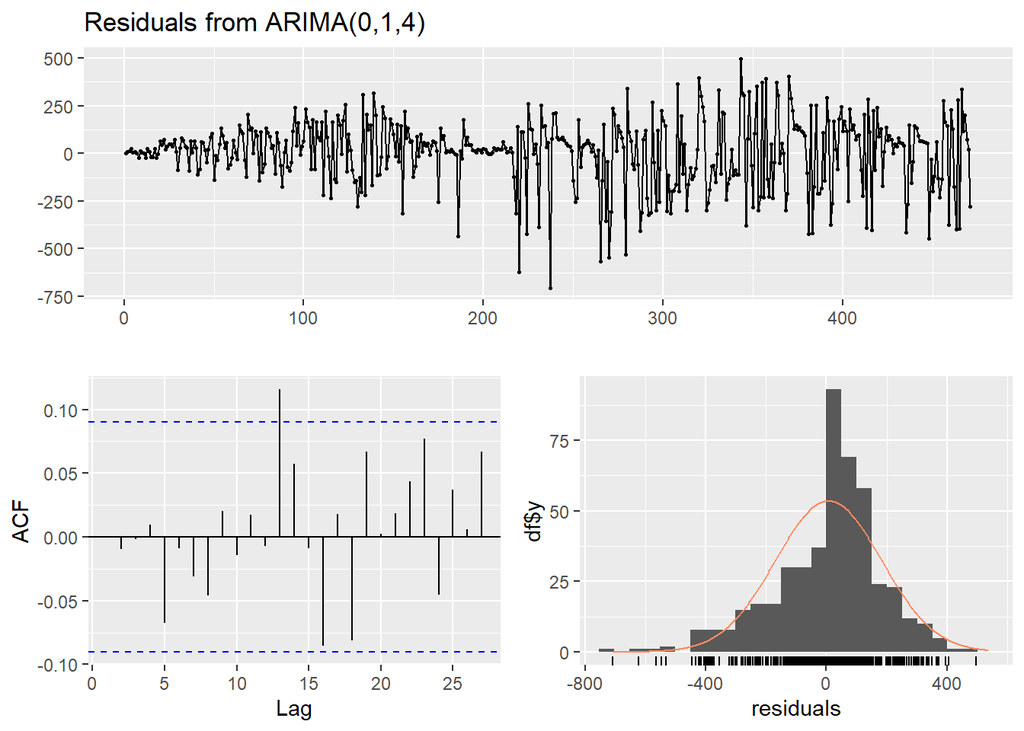

```
##
##  Ljung-Box test
##
## data:  Residuals from ARIMA(0,1,4)
## Q* = 4.0863, df = 6, p-value = 0.665
##
## Model df: 4.   Total lags used: 10
```

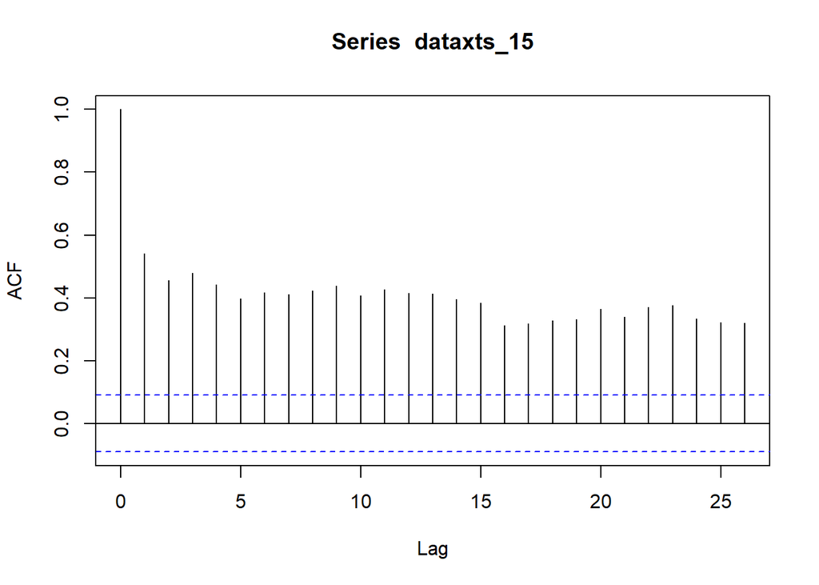

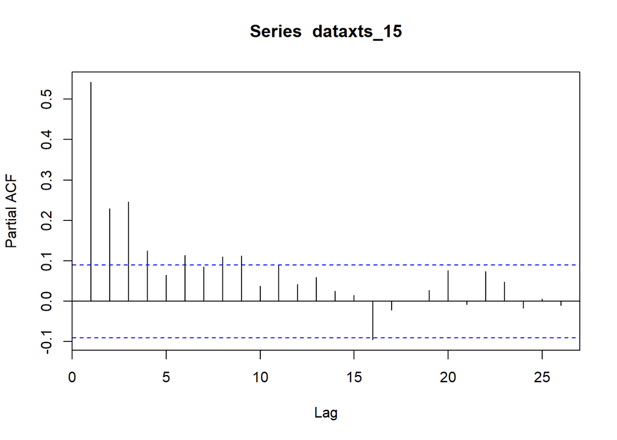

```
##
## #######################
## # KPSS Unit Root Test #
## #######################
##
## Test is of type: mu with 5 lags.
##
## Value of test-statistic is: 0.9367
##
## Critical value for a significance level of:
##                 10pct  5pct 2.5pct  1pct
## critical values 0.347 0.463  0.574 0.739
```

```
##
## #######################
## # KPSS Unit Root Test #
## #######################
##
## Test is of type: mu with 5 lags.
##
## Value of test-statistic is: 0.8807
##
## Critical value for a significance level of:
##                 10pct  5pct 2.5pct  1pct
## critical values 0.347 0.463  0.574 0.739
```

```
##
## #######################
## # KPSS Unit Root Test #
## #######################
##
## Test is of type: mu with 5 lags.
##
## Value of test-statistic is: 0.0297
##
## Critical value for a significance level of:
##                 10pct  5pct 2.5pct  1pct
## critical values 0.347 0.463  0.574 0.739
```

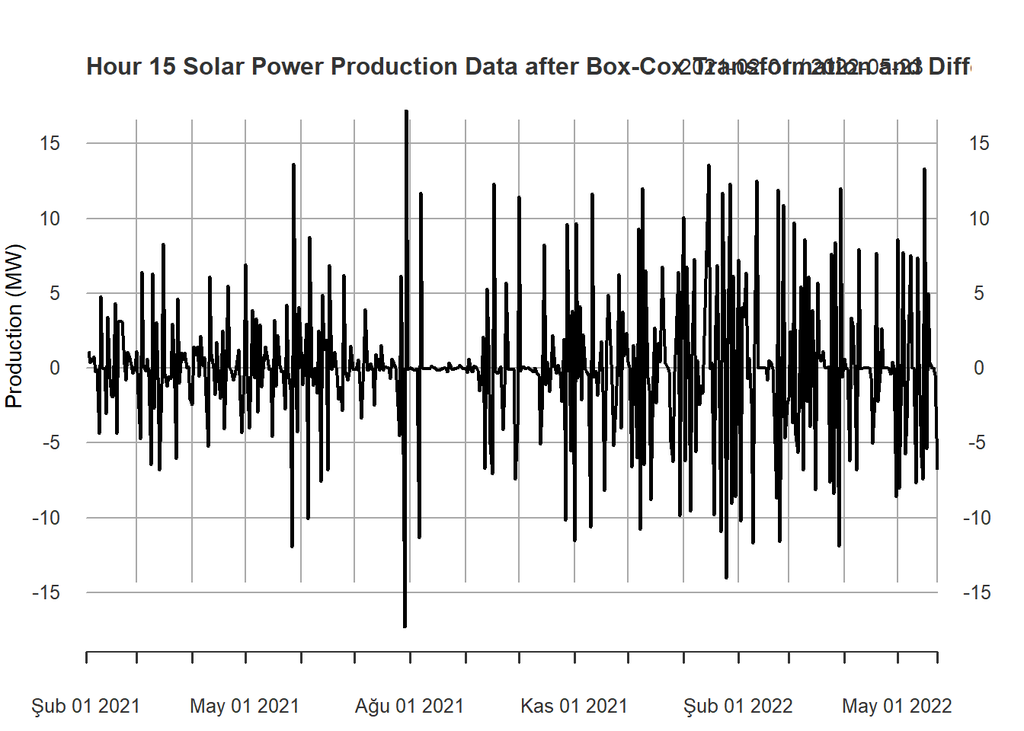

```
##
##  Fitting models using approximations to speed things up...
##
##  ARIMA(2,1,2) with drift         : 2555.476
##  ARIMA(0,1,0) with drift         : 2765.628
##  ARIMA(1,1,0) with drift         : 2681.667
##  ARIMA(0,1,1) with drift         : 2557.062
##  ARIMA(0,1,0)                    : 2763.614
##  ARIMA(1,1,2) with drift         : 2552.748
##  ARIMA(0,1,2) with drift         : 2550.855
##  ARIMA(0,1,3) with drift         : 2552.73
##  ARIMA(1,1,1) with drift         : 2551.163
##  ARIMA(1,1,3) with drift         : 2554.795
##  ARIMA(0,1,2)                    : 2549.908
##  ARIMA(0,1,1)                    : 2555.963
##  ARIMA(1,1,2)                    : 2551.703
##  ARIMA(0,1,3)                    : 2551.759
##  ARIMA(1,1,1)                    : 2550.119
##  ARIMA(1,1,3)                    : 2553.739
##
##  Now re-fitting the best model(s) without approximations...
##
##  ARIMA(0,1,2)                    : 2553.287
##
##  Best model: ARIMA(0,1,2)
```

```
## Series: box_15
## ARIMA(0,1,2)
##
## Coefficients:
##           ma1      ma2
##       -0.7544  -0.1338
## s.e.   0.0468   0.0461
##
## sigma^2 = 13.24:  log likelihood = -1273.62
## AIC=2553.24   AICc=2553.29   BIC=2565.69
```

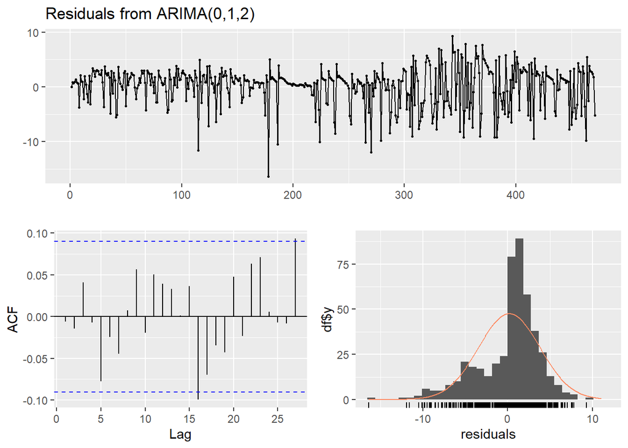

```
##
##  Ljung-Box test
##
## data:  Residuals from ARIMA(0,1,2)
## Q* = 6.805, df = 8, p-value = 0.5578
##
## Model df: 2.   Total lags used: 10
```

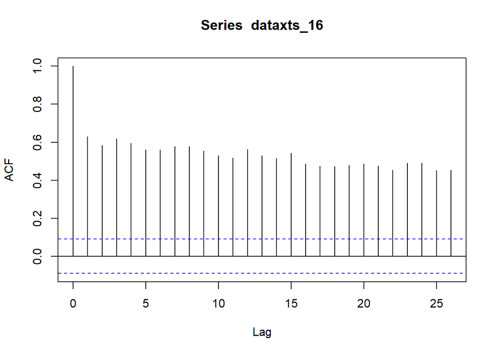

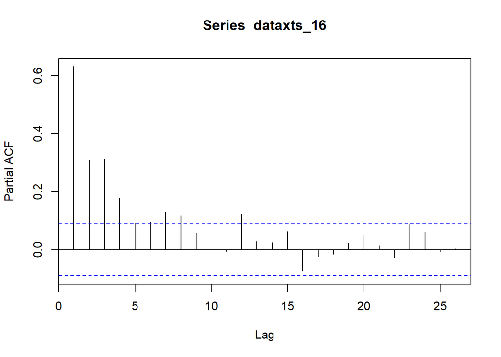

```
##
## #######################
## # KPSS Unit Root Test #
## #######################
##
## Test is of type: mu with 5 lags.
##
## Value of test-statistic is: 0.8344
##
## Critical value for a significance level of:
##                 10pct  5pct 2.5pct  1pct
## critical values 0.347 0.463  0.574 0.739
```

```
##
## #######################
## # KPSS Unit Root Test #
## #######################
##
## Test is of type: mu with 5 lags.
##
## Value of test-statistic is: 0.7956
##
## Critical value for a significance level of:
##                 10pct  5pct 2.5pct  1pct
## critical values 0.347 0.463  0.574 0.739
```

```
##
## #######################
## # KPSS Unit Root Test #
## #######################
##
## Test is of type: mu with 5 lags.
##
## Value of test-statistic is: 0.0153
##
## Critical value for a significance level of:
##                 10pct  5pct 2.5pct  1pct
## critical values 0.347 0.463  0.574 0.739
```

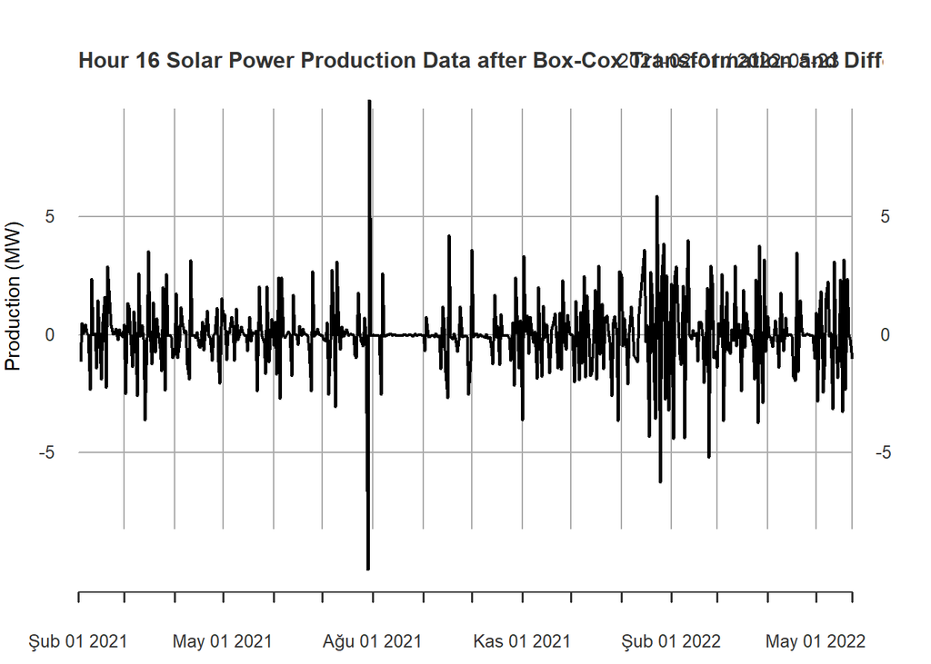

```
##
##  Fitting models using approximations to speed things up...
##
##  ARIMA(2,1,2) with drift         : 1557.927
##  ARIMA(0,1,0) with drift         : 1788.763
##  ARIMA(1,1,0) with drift         : 1703.855
##  ARIMA(0,1,1) with drift         : 1557.653
##  ARIMA(0,1,0)                    : 1786.75
##  ARIMA(1,1,1) with drift         : 1558.592
##  ARIMA(0,1,2) with drift         : 1556.015
##  ARIMA(1,1,2) with drift         : 1555.386
##  ARIMA(1,1,3) with drift         : 1557.211
##  ARIMA(0,1,3) with drift         : 1555.018
##  ARIMA(0,1,4) with drift         : 1556.636
##  ARIMA(1,1,4) with drift         : 1557.59
##  ARIMA(0,1,3)                    : 1553.625
##  ARIMA(0,1,2)                    : 1554.687
##  ARIMA(1,1,3)                    : 1556.013
##  ARIMA(0,1,4)                    : 1555.258
##  ARIMA(1,1,2)                    : 1554.198
##  ARIMA(1,1,4)                    : 1556.319
##
##  Now re-fitting the best model(s) without approximations...
##
##  ARIMA(0,1,3)                    : 1555.593
##
##  Best model: ARIMA(0,1,3)
```

```
## Series: box_16
## ARIMA(0,1,3)
##
## Coefficients:
##           ma1      ma2     ma3
##       -0.7895  -0.1623  0.0799
## s.e.   0.0459   0.0595  0.0448
##
## sigma^2 = 1.581:  log likelihood = -773.75
## AIC=1555.51   AICc=1555.59   BIC=1572.12
```

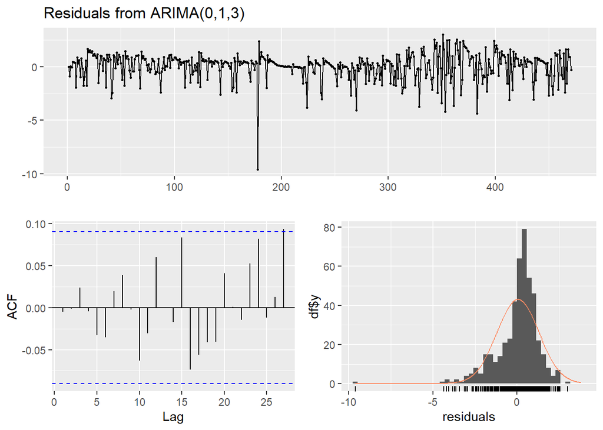

```
##
##  Ljung-Box test
##
## data:  Residuals from ARIMA(0,1,3)
## Q* = 4.2143, df = 7, p-value = 0.7548
##
## Model df: 3.   Total lags used: 10
```

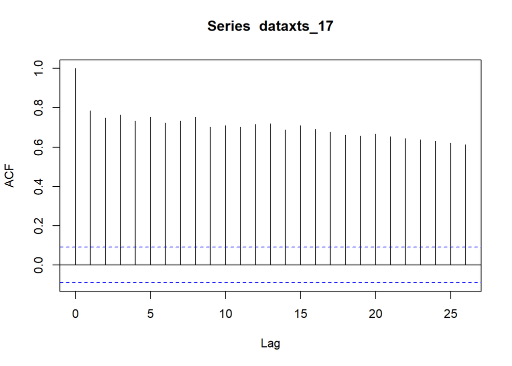

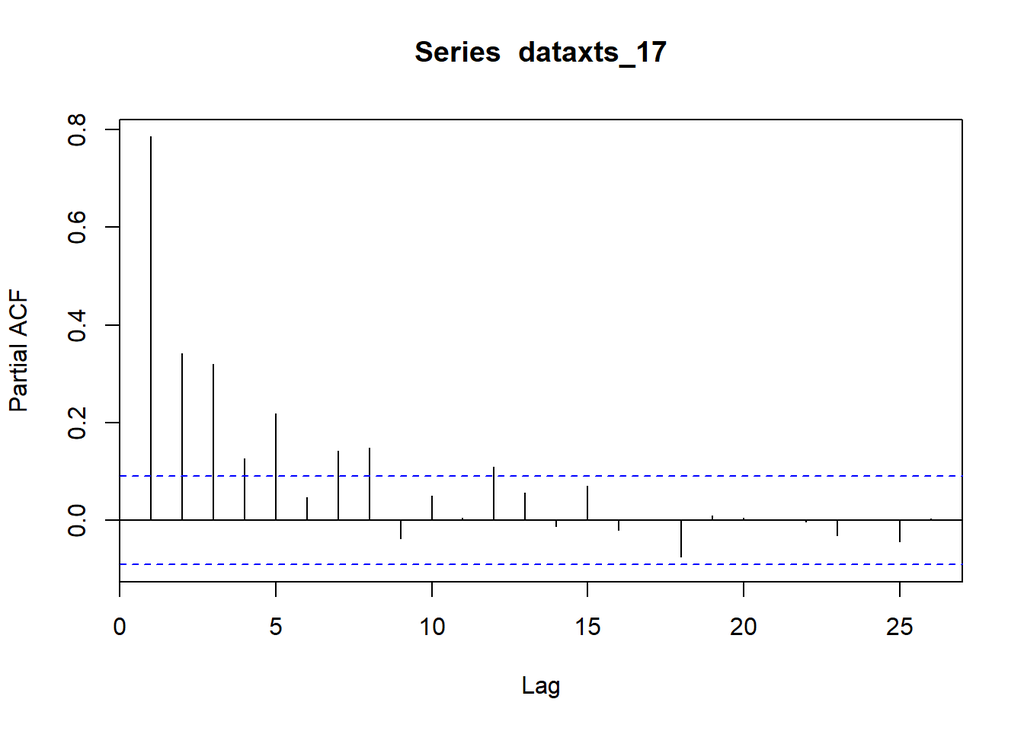

```
##
## #######################
## # KPSS Unit Root Test #
## #######################
##
## Test is of type: mu with 5 lags.
##
## Value of test-statistic is: 1.0778
##
## Critical value for a significance level of:
##                 10pct  5pct 2.5pct  1pct
## critical values 0.347 0.463  0.574 0.739
```

```
##
## #######################
## # KPSS Unit Root Test #
## #######################
##
## Test is of type: mu with 5 lags.
##
## Value of test-statistic is: 1.1609
##
## Critical value for a significance level of:
##                 10pct  5pct 2.5pct  1pct
## critical values 0.347 0.463  0.574 0.739
```

```
##
## #######################
## # KPSS Unit Root Test #
## #######################
##
## Test is of type: mu with 5 lags.
##
## Value of test-statistic is: 0.0227
##
## Critical value for a significance level of:
##                 10pct  5pct 2.5pct  1pct
## critical values 0.347 0.463  0.574 0.739
```

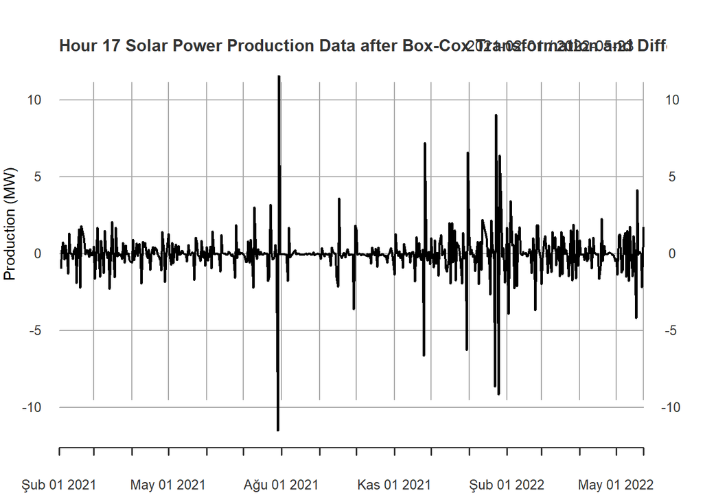

```
##
##  Fitting models using approximations to speed things up...
##
##  ARIMA(2,1,2) with drift         : 1524.31
##  ARIMA(0,1,0) with drift         : 1767.574
##  ARIMA(1,1,0) with drift         : 1680.389
##  ARIMA(0,1,1) with drift         : 1526.247
##  ARIMA(0,1,0)                    : 1765.566
##  ARIMA(1,1,2) with drift         : 1523.414
##  ARIMA(0,1,2) with drift         : 1527.402
##  ARIMA(1,1,1) with drift         : 1530.11
##  ARIMA(1,1,3) with drift         : 1522.998
##  ARIMA(0,1,3) with drift         : 1520.826
##  ARIMA(0,1,4) with drift         : 1522.27
##  ARIMA(1,1,4) with drift         : 1524.776
##  ARIMA(0,1,3)                    : 1519.409
##  ARIMA(0,1,2)                    : 1526.018
##  ARIMA(1,1,3)                    : 1521.696
##  ARIMA(0,1,4)                    : 1520.852
##  ARIMA(1,1,2)                    : 1522.121
##  ARIMA(1,1,4)                    : 1523.433
##
##  Now re-fitting the best model(s) without approximations...
##
##  ARIMA(0,1,3)                    : 1521.631
##
##  Best model: ARIMA(0,1,3)
```

```
## Series: box_17
## ARIMA(0,1,3)
##
## Coefficients:
##           ma1      ma2     ma3
##       -0.8038  -0.1834  0.1385
## s.e.   0.0462   0.0628  0.0472
##
## sigma^2 = 1.471:  log likelihood = -756.77
## AIC=1521.54   AICc=1521.63   BIC=1538.16
```

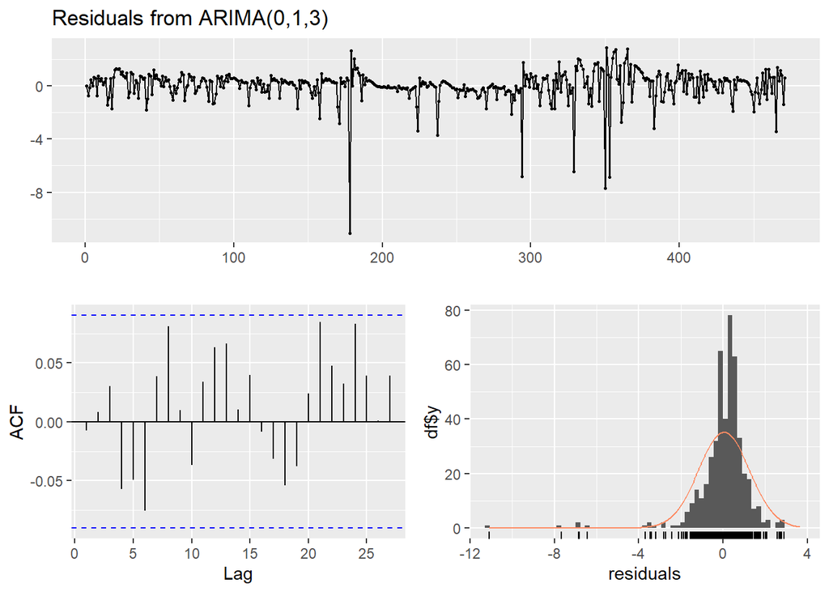

```
##
##  Ljung-Box test
##
## data:  Residuals from ARIMA(0,1,3)
## Q* = 10.538, df = 7, p-value = 0.1601
##
## Model df: 3.   Total lags used: 10
```

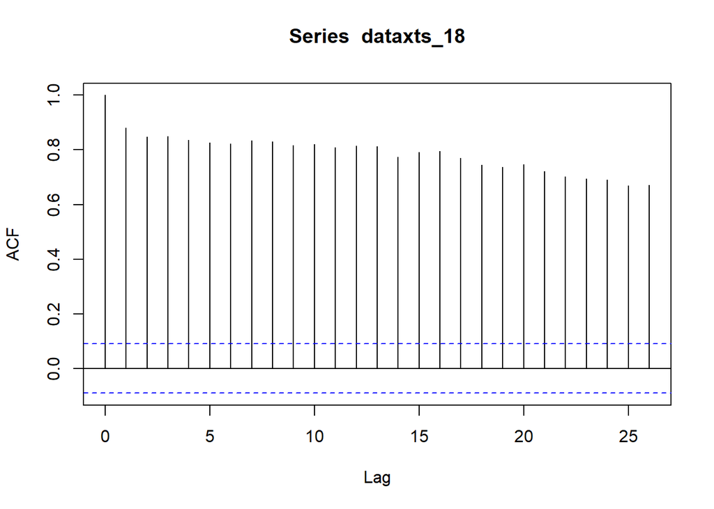

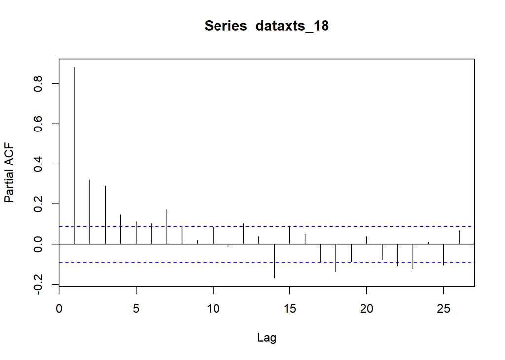

```
##
## #######################
## # KPSS Unit Root Test #
## #######################
##
## Test is of type: mu with 5 lags.
##
## Value of test-statistic is: 1.165
##
## Critical value for a significance level of:
##                 10pct  5pct 2.5pct  1pct
## critical values 0.347 0.463  0.574 0.739
```

```
##
## #######################
## # KPSS Unit Root Test #
## #######################
##
## Test is of type: mu with 5 lags.
##
## Value of test-statistic is: 0.9948
##
## Critical value for a significance level of:
##                 10pct  5pct 2.5pct  1pct
## critical values 0.347 0.463  0.574 0.739
```

```
##
## #######################
## # KPSS Unit Root Test #
## #######################
##
## Test is of type: mu with 5 lags.
##
## Value of test-statistic is: 0.189
##
## Critical value for a significance level of:
##                 10pct  5pct 2.5pct  1pct
## critical values 0.347 0.463  0.574 0.739
```

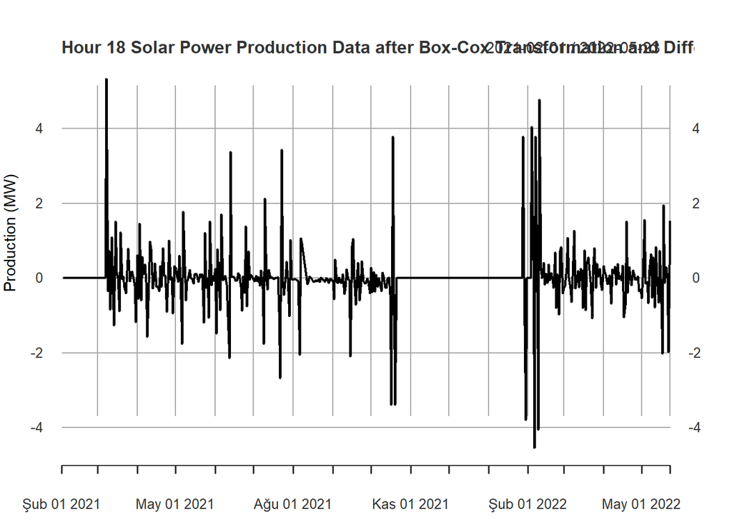

```
##
##  Fitting models using approximations to speed things up...
##
##  ARIMA(2,1,2) with drift         : 1073.084
##  ARIMA(0,1,0) with drift         : 1179.523
##  ARIMA(1,1,0) with drift         : 1137.632
##  ARIMA(0,1,1) with drift         : 1089.25
##  ARIMA(0,1,0)                    : 1177.712
##  ARIMA(1,1,2) with drift         : 1072.019
##  ARIMA(0,1,2) with drift         : 1082.75
##  ARIMA(1,1,1) with drift         : 1087.752
##  ARIMA(1,1,3) with drift         : 1072.071
##  ARIMA(0,1,3) with drift         : 1070.577
##  ARIMA(0,1,4) with drift         : 1071.54
##  ARIMA(1,1,4) with drift         : 1074.131
##  ARIMA(0,1,3)                    : 1069.629
##  ARIMA(0,1,2)                    : 1082.018
##  ARIMA(1,1,3)                    : 1071.15
##  ARIMA(0,1,4)                    : 1070.63
##  ARIMA(1,1,2)                    : 1071.214
##  ARIMA(1,1,4)                    : Inf
##
##  Now re-fitting the best model(s) without approximations...
##
##  ARIMA(0,1,3)                    : 1069.724
##
##  Best model: ARIMA(0,1,3)
```

```
## Series: box_18
## ARIMA(0,1,3)
##
## Coefficients:
##           ma1      ma2     ma3
##       -0.4206  -0.2627  0.1665
## s.e.   0.0460   0.0519  0.0436
##
## sigma^2 = 0.5635:  log likelihood = -530.82
## AIC=1069.64   AICc=1069.72   BIC=1086.25
```

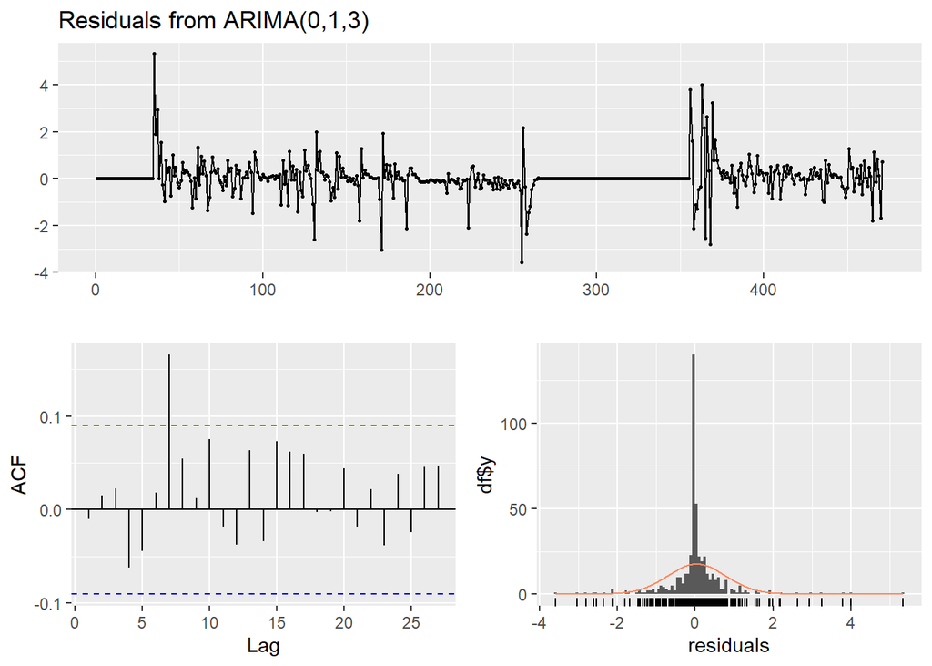

```
##
##  Ljung-Box test
##
## data:  Residuals from ARIMA(0,1,3)
## Q* = 20.672, df = 7, p-value = 0.004288
##
## Model df: 3.   Total lags used: 10
```

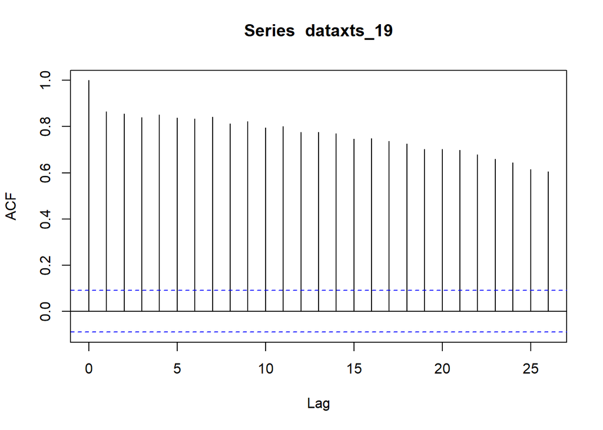

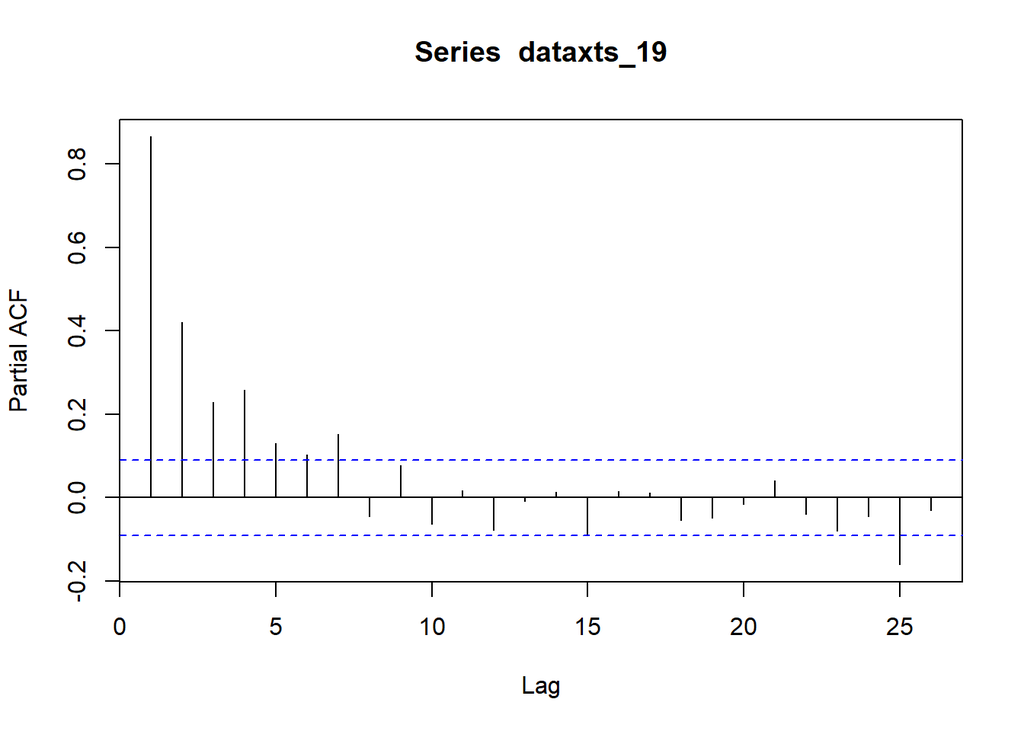

```
##
## #######################
## # KPSS Unit Root Test #
## #######################
##
## Test is of type: mu with 5 lags.
##
## Value of test-statistic is: 1.2317
##
## Critical value for a significance level of:
##                 10pct  5pct 2.5pct  1pct
## critical values 0.347 0.463  0.574 0.739
```

```
##
## #######################
## # KPSS Unit Root Test #
## #######################
##
## Test is of type: mu with 5 lags.
##
## Value of test-statistic is: 1.2244
##
## Critical value for a significance level of:
##                 10pct  5pct 2.5pct  1pct
## critical values 0.347 0.463  0.574 0.739
```

```
##
## #######################
## # KPSS Unit Root Test #
## #######################
##
## Test is of type: mu with 5 lags.
##
## Value of test-statistic is: 0.1915
##
## Critical value for a significance level of:
##                 10pct  5pct 2.5pct  1pct
## critical values 0.347 0.463  0.574 0.739
```

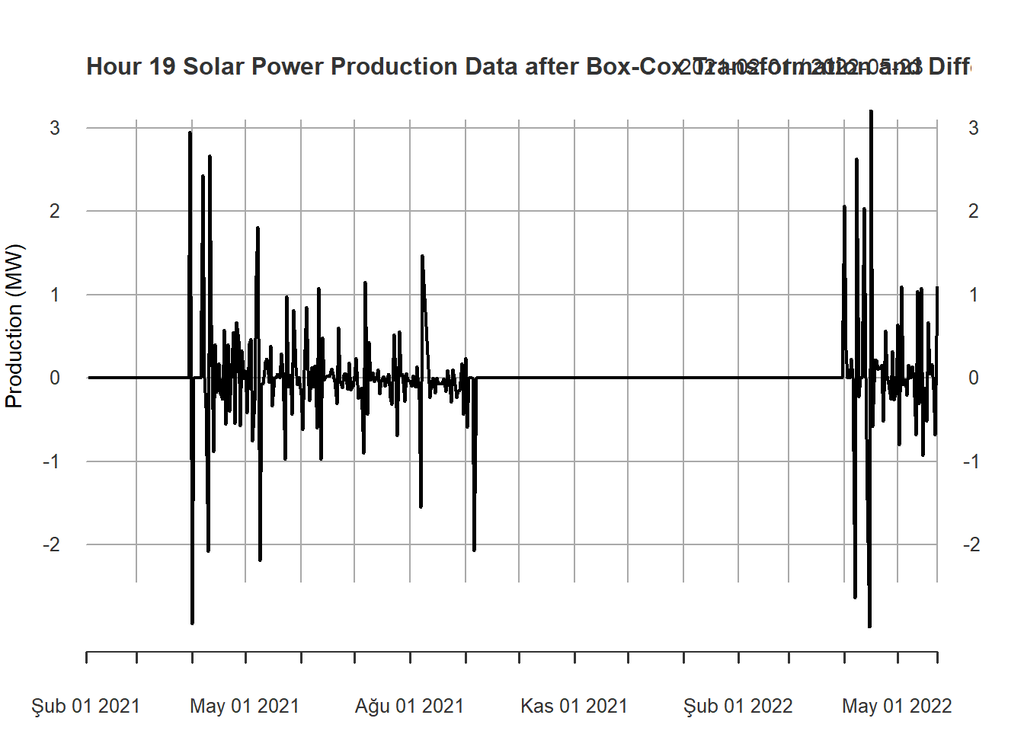

```
##
##  Fitting models using approximations to speed things up...
##
##  ARIMA(2,1,2) with drift         : 596.753
##  ARIMA(0,1,0) with drift         : 717.3445
##  ARIMA(1,1,0) with drift         : 656.4773
##  ARIMA(0,1,1) with drift         : 606.7917
##  ARIMA(0,1,0)                    : 715.5101
##  ARIMA(1,1,2) with drift         : 608.5688
##  ARIMA(2,1,1) with drift         : 607.3668
##  ARIMA(3,1,2) with drift         : 599.9621
##  ARIMA(2,1,3) with drift         : 582.3209
##  ARIMA(1,1,3) with drift         : 595.1077
##  ARIMA(3,1,3) with drift         : 584.4396
##  ARIMA(2,1,4) with drift         : 583.327
##  ARIMA(1,1,4) with drift         : 596.5572
##  ARIMA(3,1,4) with drift         : 573.3268
##  ARIMA(4,1,4) with drift         : 576.33
##  ARIMA(3,1,5) with drift         : 575.3264
##  ARIMA(2,1,5) with drift         : 584.8892
##  ARIMA(4,1,3) with drift         : 587.0091
##  ARIMA(4,1,5) with drift         : Inf
##  ARIMA(3,1,4)                    : 571.596
##  ARIMA(2,1,4)                    : 582.3366
##  ARIMA(3,1,3)                    : 583.5016
##  ARIMA(4,1,4)                    : 574.5937
##  ARIMA(3,1,5)                    : 573.5898
##  ARIMA(2,1,3)                    : 581.3959
##  ARIMA(2,1,5)                    : 583.8593
##  ARIMA(4,1,3)                    : 586.0371
##  ARIMA(4,1,5)                    : Inf
##
##  Now re-fitting the best model(s) without approximations...
##
##  ARIMA(3,1,4)                    : 568.8812
##
##  Best model: ARIMA(3,1,4)
```

```
## Series: box_19
## ARIMA(3,1,4)
##
## Coefficients:
##          ar1      ar2     ar3      ma1     ma2      ma3     ma4
##       0.4287  -0.3314  0.8159  -0.9604  0.4707  -1.0606  0.6287
## s.e.  0.0518   0.0481  0.0528   0.0488  0.0445   0.0583  0.0391
##
## sigma^2 = 0.1919:  log likelihood = -276.28
## AIC=568.57   AICc=568.88   BIC=601.79
```

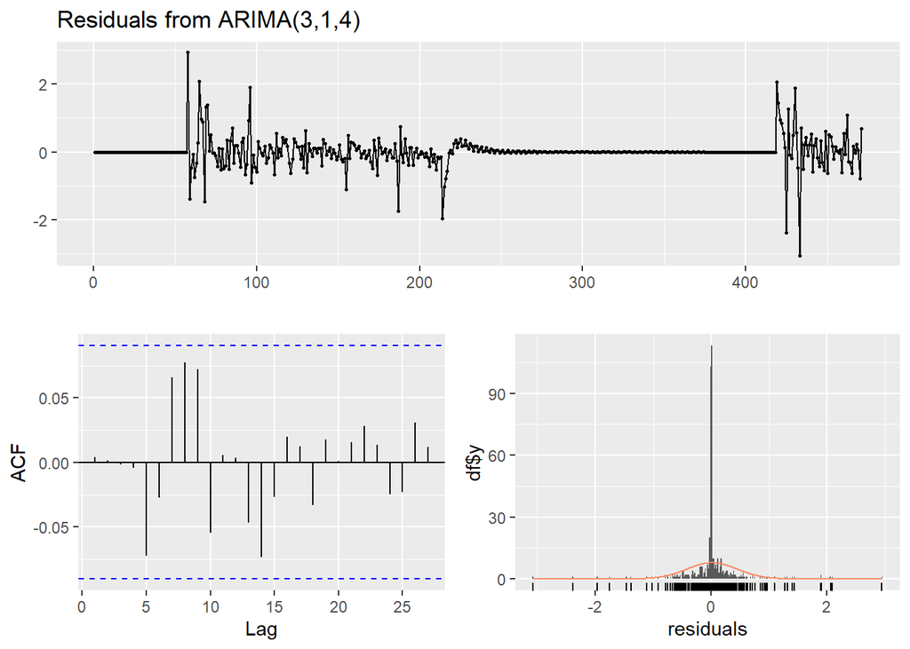

```
##
##  Ljung-Box test
##
## data:  Residuals from ARIMA(3,1,4)
## Q* = 11.809, df = 3, p-value = 0.008066
##
## Model df: 7.   Total lags used: 10
```

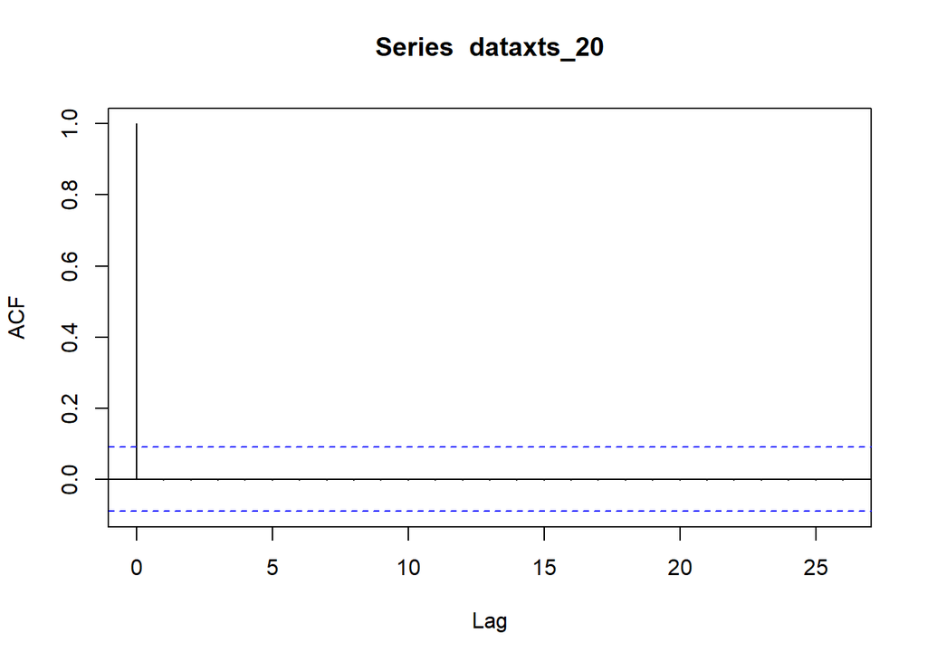

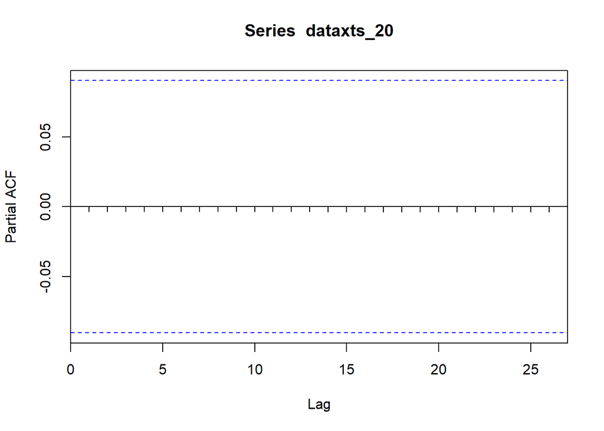

```
##
## #######################
## # KPSS Unit Root Test #
## #######################
##
## Test is of type: mu with 5 lags.
##
## Value of test-statistic is: 0.0992
##
## Critical value for a significance level of:
##                 10pct  5pct 2.5pct  1pct
## critical values 0.347 0.463  0.574 0.739
```

```
##
## #######################
## # KPSS Unit Root Test #
## #######################
##
## Test is of type: mu with 5 lags.
##
## Value of test-statistic is: 0.0741
##
## Critical value for a significance level of:
##                 10pct  5pct 2.5pct  1pct
## critical values 0.347 0.463  0.574 0.739
```

```
##
## #######################
## # KPSS Unit Root Test #
## #######################
##
## Test is of type: mu with 5 lags.
##
## Value of test-statistic is: 0.0064
##
## Critical value for a significance level of:
##                 10pct  5pct 2.5pct  1pct
## critical values 0.347 0.463  0.574 0.739
```

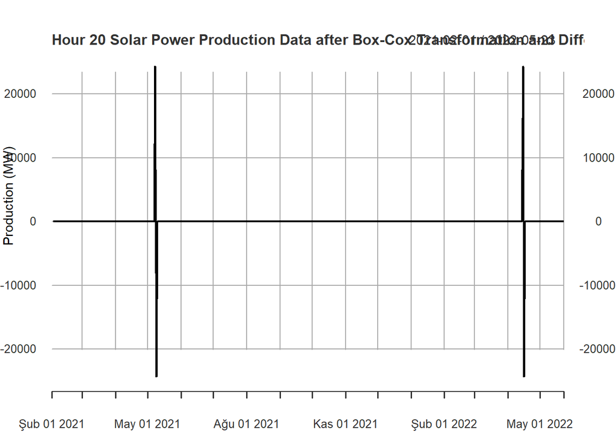

```
##
##  Fitting models using approximations to speed things up...
##
##  ARIMA(2,1,2) with drift         : Inf
##  ARIMA(0,1,0) with drift         : 8577.419
##  ARIMA(1,1,0) with drift         : 8445.235
##  ARIMA(0,1,1) with drift         : Inf
##  ARIMA(0,1,0)                    : 8575.402
##  ARIMA(2,1,0) with drift         : 8392.915
##  ARIMA(3,1,0) with drift         : 8365.63
##  ARIMA(4,1,0) with drift         : 8349.504
##  ARIMA(5,1,0) with drift         : 8339.334
##  ARIMA(5,1,1) with drift         : Inf
##  ARIMA(4,1,1) with drift         : Inf
##  ARIMA(5,1,0)                    : 8337.273
##  ARIMA(4,1,0)                    : 8347.452
##  ARIMA(5,1,1)                    : Inf
##  ARIMA(4,1,1)                    : Inf
##
##  Now re-fitting the best model(s) without approximations...
##
##  ARIMA(5,1,0)                    : 8348.7
##
##  Best model: ARIMA(5,1,0)
```

```
## Series: box_20
## ARIMA(5,1,0)
##
## Coefficients:
##           ar1      ar2      ar3      ar4      ar5
##       -0.8316  -0.6638  -0.4968  -0.3305  -0.1649
## s.e.   0.0455   0.0575   0.0609   0.0573   0.0452
##
## sigma^2 = 2981493:  log likelihood = -4168.26
## AIC=8348.52   AICc=8348.7   BIC=8373.44
```

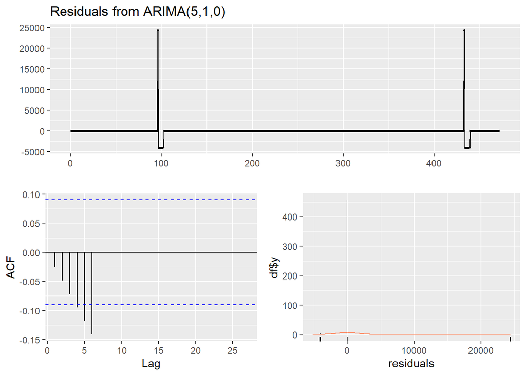

```
##
##  Ljung-Box test
##
## data:  Residuals from ARIMA(5,1,0)
## Q* = 24.417, df = 5, p-value = 0.0001805
##
## Model df: 5.   Total lags used: 10
```

```
##           date hour      arima
##  1: 2022-05-26    0  0.0000000
##  2: 2022-05-26    1  0.0000000
##  3: 2022-05-26    2  0.0000000
##  4: 2022-05-26    3  0.0000000
##  5: 2022-05-26    4  0.0000000
##  6: 2022-05-26    5  0.1192190
##  7: 2022-05-26    6  6.5347874
##  8: 2022-05-26    7 25.3097093
##  9: 2022-05-26    8 31.8310197
## 10: 2022-05-26    9 32.1608702
## 11: 2022-05-26   10 34.0857430
## 12: 2022-05-26   11 34.1727772
## 13: 2022-05-26   12 33.4542150
## 14: 2022-05-26   13 30.1449889
## 15: 2022-05-26   14 28.1285354
## 16: 2022-05-26   15 26.1497283
## 17: 2022-05-26   16 22.8237464
## 18: 2022-05-26   17 14.8639103
## 19: 2022-05-26   18  5.9916079
## 20: 2022-05-26   19  0.8968618
## 21: 2022-05-26   20  0.0000000
## 22: 2022-05-26   21  0.0000000
## 23: 2022-05-26   22  0.0000000
## 24: 2022-05-26   23  0.0000000
##           date hour      arima
```

```
##            date hour     arima
##   1: 2022-05-26    0 0.0000000
##   2: 2022-05-26    1 0.0000000
##   3: 2022-05-26    2 0.0000000
##   4: 2022-05-26    3 0.0000000
##   5: 2022-05-26    4 0.0000000
##  ---
## 212: 2022-06-03   19 0.2262208
## 213: 2022-06-03   20 0.0000000
## 214: 2022-06-03   21 0.0000000
## 215: 2022-06-03   22 0.0000000
## 216: 2022-06-03   23 0.0000000
```

After printing the final forecast data, it is also useful to analyze error statistics.

Statistics for Hourly Solar Power Production using ARIMA

| N | Mean | Standard Deviation | Bias | MAD | WMAPE |
| --- | --- | --- | --- | --- | --- |
| 216 | 16.08218 | 16.96724 | 0.124013 | 2.657284 | 0.1652316 |

WMAPE statistic is an important measurement to look for in terms of model performance. This WMAPE value is small, and hence it can be concluded that this model is valid.

# 3 SARIMA Modeling

SARIMA modeling for the whole time series is done below. The KPSS test reveals that the data is not stationary, however I could not do the differencing method for this model, that is why it may be prone to some errors.

Again, I ran the code multiple times with different dates to obtain the forecast data for the competition phase time period. Important Note: The sarima_model was obtained to be ARIMA(2,0,1)(2,1,0)[24] with drift in the original R code, however it took too long to compute in the RMD file, that is why I put the commented codes at the end. But I was able to compute the final forecast data regardless.

```
##
## #######################
## # KPSS Unit Root Test #
## #######################
##
## Test is of type: mu with 13 lags.
##
## Value of test-statistic is: 2.8637
##
## Critical value for a significance level of:
##                 10pct  5pct 2.5pct  1pct
## critical values 0.347 0.463  0.574 0.739
```

```
##   [1]  0.1162341  0.1235566  0.1287468  0.1325634  0.1353361  0.3113367
##   [7]  7.1610356 26.3844525 35.1354915 35.1392497 35.1289192 35.1419747
##  [13] 35.1161013 34.7413522 33.3145821 27.4023235 25.2168704 21.4118604
##  [19]  9.6324562  1.3767815  0.1427402  0.1427529  0.1427622  0.1427690
##  [25]  0.1162341  0.1235566  0.1287468  0.1325634  0.1353361  0.3113367
##  [31]  7.1610356 26.3844525 35.1354915 35.1392497 35.1289192 35.1419747
##  [37] 35.1161013 34.7413522 33.3145821 27.4023235 25.2168704 21.4118604
##  [43]  9.6324562  1.3767815  0.1427402  0.1427529  0.1427622  0.1427690
##  [49]  0.1162341  0.1235566  0.1287468  0.1325634  0.1353361  0.3113367
##  [55]  7.1610356 26.3844525 35.1354915 35.1392497 35.1289192 35.1419747
##  [61] 35.1161013 34.7413522 33.3145821 27.4023235 25.2168704 21.4118604
##  [67]  9.6324562  1.3767815  0.1427402  0.1427529  0.1427622  0.1427690
##  [73]  0.1162341  0.1235566  0.1287468  0.1325634  0.1353361  0.3113367
##  [79]  7.1610356 26.3844525 35.1354915 35.1392497 35.1289192 35.1419747
##  [85] 35.1161013 34.7413522 33.3145821 27.4023235 25.2168704 21.4118604
```

[output cut: 21 more lines]

Error statistics for this model are given below.

Statistics for Solar Power Production using SARIMA

| N | Mean | Standard Deviation | Bias | MAD | WMAPE |
| --- | --- | --- | --- | --- | --- |
| 216 | 16.08218 | 16.96724 | 0.0573875 | 1.904071 | 0.1183964 |

Surprisingly, the WMAPE value turned out to be better than the first ARIMA model.

## 4 ARIMAX Model with One Regressor

In this model, the most correlated DSWRF variable out of nine coordinates is chosen via correlation tests given below.

```
##
##  Pearson's product-moment correlation
##
## data:  data_production$production[1:11616] and data_weather$DSWRF_36.25_33
## t = 94.384, df = 11302, p-value < 2.2e-16
## alternative hypothesis: true correlation is greater than 0
## 95 percent confidence interval:
##  0.6551736 1.0000000
## sample estimates:
##       cor
## 0.6639154
```

```
##
##  Pearson's product-moment correlation
##
## data:  data_production$production[1:11616] and data_weather$DSWRF_36.25_33.25
## t = 95.071, df = 11302, p-value < 2.2e-16
## alternative hypothesis: true correlation is greater than 0
## 95 percent confidence interval:
##  0.6579159 1.0000000
## sample estimates:
##       cor
## 0.6666021
```

```
##
##  Pearson's product-moment correlation
##
## data:  data_production$production[1:11616] and data_weather$DSWRF_36.25_33.5
## t = 96.029, df = 11302, p-value < 2.2e-16
## alternative hypothesis: true correlation is greater than 0
## 95 percent confidence interval:
##  0.6617003 1.0000000
## sample estimates:
##       cor
## 0.6703095
```

```
##
##  Pearson's product-moment correlation
##
## data:  data_production$production[1:11616] and data_weather$DSWRF_36.5_33
## t = 93.589, df = 11302, p-value < 2.2e-16
## alternative hypothesis: true correlation is greater than 0
## 95 percent confidence interval:
##  0.6519606 1.0000000
## sample estimates:
##       cor
## 0.6607671
```

```
##
##  Pearson's product-moment correlation
##
## data:  data_production$production[1:11616] and data_weather$DSWRF_36.5_33.25
## t = 93.923, df = 11302, p-value < 2.2e-16
## alternative hypothesis: true correlation is greater than 0
## 95 percent confidence interval:
##  0.6533138 1.0000000
## sample estimates:
##       cor
## 0.6620931
```

```
##
##  Pearson's product-moment correlation
##
## data:  data_production$production[1:11616] and data_weather$DSWRF_36.5_33.5
## t = 95.284, df = 11302, p-value < 2.2e-16
## alternative hypothesis: true correlation is greater than 0
## 95 percent confidence interval:
##  0.6587644 1.0000000
## sample estimates:
##       cor
## 0.6674334
```

```
##
##  Pearson's product-moment correlation
##
## data:  data_production$production[1:11616] and data_weather$DSWRF_36.75_33
## t = 94.899, df = 11302, p-value < 2.2e-16
## alternative hypothesis: true correlation is greater than 0
## 95 percent confidence interval:
##  0.6572327 1.0000000
## sample estimates:
##       cor
## 0.6659327
```

```
##
##  Pearson's product-moment correlation
##
## data:  data_production$production[1:11616] and data_weather$DSWRF_36.75_33.25
## t = 95.724, df = 11302, p-value < 2.2e-16
## alternative hypothesis: true correlation is greater than 0
## 95 percent confidence interval:
##  0.6605009 1.0000000
## sample estimates:
##       cor
## 0.6691346
```

```
##
##  Pearson's product-moment correlation
##
## data:  data_production$production[1:11616] and data_weather$DSWRF_36.75_33.5
## t = 95.439, df = 11302, p-value < 2.2e-16
## alternative hypothesis: true correlation is greater than 0
## 95 percent confidence interval:
##  0.6593765 1.0000000
## sample estimates:
##       cor
## 0.6680331
```

```
##
## #######################
## # KPSS Unit Root Test #
## #######################
##
## Test is of type: mu with 13 lags.
##
## Value of test-statistic is: 2.8637
##
## Critical value for a significance level of:
##                 10pct  5pct 2.5pct  1pct
## critical values 0.347 0.463  0.574 0.739
```

```
## [1] 1
```

```
##
## #######################
## # KPSS Unit Root Test #
## #######################
##
## Test is of type: mu with 13 lags.
##
## Value of test-statistic is: 6e-04
##
## Critical value for a significance level of:
##                 10pct  5pct 2.5pct  1pct
## critical values 0.347 0.463  0.574 0.739
```

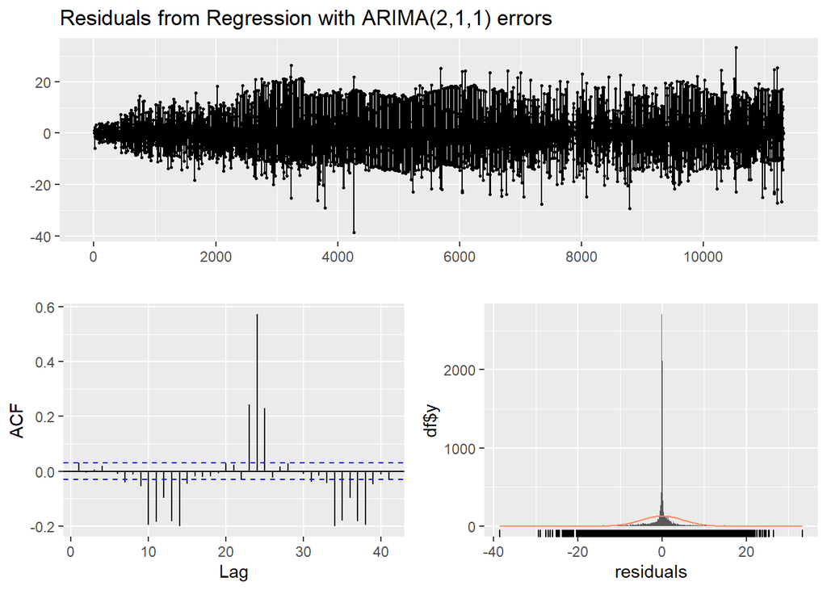

```
##
##  Ljung-Box test
##
## data:  Residuals from Regression with ARIMA(2,1,1) errors
## Q* = 455.71, df = 6, p-value < 2.2e-16
##
## Model df: 4.   Total lags used: 10
```

```
##  [1] 237.5136 237.5136 237.5136 237.5136 237.5136 237.5136 237.5136 237.5136
##  [9] 237.5136 237.5136 237.5136 237.5136 237.5136 237.5136 237.5136 237.5136
## [17] 237.5136 237.5136 237.5136 237.5136 237.5136 237.5136 237.5136 237.5136
## [25] 237.5136 237.5136 237.5136 237.5136 237.5136 237.5136 237.5136 237.5136
## [33] 237.5136 237.5136 237.5136 237.5136 237.5136 237.5136 237.5136 237.5136
## [41] 237.5136 237.5136 237.5136 237.5136 237.5136 237.5136 237.5136 237.5136
## [49] 237.5136 237.5136 237.5136 237.5136 237.5136 237.5136 237.5136 237.5136
## [57] 237.5136 237.5136 237.5136 237.5136 237.5136 237.5136 237.5136 237.5136
## [65] 237.5136 237.5136 237.5136 237.5136 237.5136 237.5136 237.5136 237.5136
```

```
##       Point Forecast      Lo 80     Hi 80       Lo 95      Hi 95
## 11311      0.2270239  -6.137511  6.591559   -9.506693   9.960741
## 11312      0.2287154 -11.598705 12.056136  -17.859763  18.317194
## 11313      0.2290119 -15.817235 16.275258  -24.311604  24.769628
## 11314      0.2289975 -19.171625 19.629620  -29.441695  29.899690
## 11315      0.2289702 -22.005377 22.463317  -33.775529  34.233469
## 11316      0.2289611 -24.507834 24.965757  -37.602703  38.060625
## 11317      0.2289597 -26.777631 27.235550  -41.074056  41.531975
## 11318      0.2289598 -28.870858 29.328778  -44.275371  44.733291
## 11319      0.2289600 -30.823394 31.281314  -47.261518  47.719438
## 11320      0.2289600 -32.660255 33.118175  -50.070753  50.528673
## 11321      0.2289600 -34.399823 34.857744  -52.731194  53.189114
## 11322      0.2289600 -36.056090 36.514010  -55.264235  55.722155
## 11323      0.2289600 -37.639985 38.097905  -57.686594  58.144514
## 11324      0.2289600 -39.160241 39.618161  -60.011625  60.469545
```

[output cut: 58 more lines]

The actual forecast values are seen in the point forecast column and between rows 49-72. Since these values highly deviate from the other two models and the actual past data, I did not calculate the rest of the forecasts or WMAPE value.

## 5 Conclusion

Before constructing the models, the data is visualized by various plots, corresponding ACF and PACF plots are given. In addition, stationarity is checked via KPSS tests and transformations are done in order to make the time series data stationary. The exception is the second model, in which I could not perform differencing.

Most important comparison parameter is WMAPE statistic, when the two models are compared the second one obtains the lowest WMAPE, even though I have not performed differencing for that. That is why I can’t propose an exact statement as to which one is better, but I can state that the two models have low WMAPE values, meaning they can be used as a prediction model. For the third model, I did not calculate the WMAPE values since the data already differed much when compared to others. So, I do not think it is a valid model.